# Observational Study on COVID-19 Vaccination Uptake R Code

Lavinia Xu

## Part 1: Create a contingency table to summarize vaccination uptake and trust

```
##
##                High Trust Low Trust
##   Vaccinated         2558      6079
##   Unvaccinated        314      1425
```

```
##
##                High Trust Low Trust
##   Vaccinated     89.06685  81.01013
##   Unvaccinated   10.93315  18.98987
```

$H_{0}:$ There is no association between COVID vaccination status and trust in elected officials. $H_{a}:$ There is an association between COVID vaccination status and trust in elected officials.

$\alpha = 0.05$

In this case we chose to do a Chi-Squared test of independence. This tests if X = E(X). The expected value of each portion can be represented by the following equation:

$\text{Expected frequency} = ( \frac{{\text{Grand total}}}{{(\text{Row total} \times \text{Column total})}} )$

```
## P-Value of Chi-Sq Test: 1.112049e-22
```

In this test our p-value is far below our $\alpha = 0.05$, meaning we have sufficient evidence to reject the null hypothesis that there is no association between COVID vaccination status and trust in elected officials. In practicality, this means that there is likely an association between COVID vaccination status and trust in elected officials.

## Part 2: Stratify by age group and redo the test

It is natural to assume that age group can play a key role in both vaccination status and trust in the government. Thus, we should preform the test while stratifying for age groups.

```
## Age Group: 18-29
##
##                High Trust Low Trust
##   Vaccinated          174       501
##   Unvaccinated         38       125
##
## Age Group: 30-49
##
##                High Trust Low Trust
##   Vaccinated          779      1855
##   Unvaccinated        157       571
##
## Age Group: 50-64
##
##                High Trust Low Trust
##   Vaccinated          740      1696
##   Unvaccinated         66       468
##
## Age Group: 65+
##
##                High Trust Low Trust
##   Vaccinated          859      2007
##   Unvaccinated         52       259
##
## Age Group: Refused
##
##                High Trust Low Trust
##   Vaccinated            6        20
##   Unvaccinated          1         2
```

```
## Age Group: 18-29
##
##                High Trust Low Trust
##   Vaccinated     82.07547  80.03195
##   Unvaccinated   17.92453  19.96805
##
## Age Group: 30-49
##
##                High Trust Low Trust
##   Vaccinated     83.22650  76.46331
##   Unvaccinated   16.77350  23.53669
##
## Age Group: 50-64
##
##                High Trust Low Trust
##   Vaccinated    91.811414 78.373383
##   Unvaccinated   8.188586 21.626617
##
## Age Group: 65+
##
##                High Trust Low Trust
##   Vaccinated    94.291987 88.570168
##   Unvaccinated   5.708013 11.429832
##
## Age Group: Refused
##
##                High Trust Low Trust
##   Vaccinated    85.714286 90.909091
##   Unvaccinated  14.285714  9.090909
```

Now we will preform the same Chi-Squared test as before for each age group.

|  | Age_Group | P_Value |
| --- | --- | --- |
| 18-29 | 18-29 | 5.827860e-01 |
| 30-49 | 30-49 | 2.435949e-05 |
| 50-64 | 50-64 | 3.565592e-17 |
| 65+ | 65+ | 1.284771e-06 |
| Refused | Refused | 1.000000e+00 |

As we can see from the results, we have sufficient evidence to reject the null hypothesis for age groups 30-49, 50-64, and 65+. However, we do not have sufficient evidence to reject the null hypothesis for the age group of 18-29 and those who refused to give age information. This means that for individuals 30+, there is likely an association between trust and vaccination. However, for those in the range of 18-29 there is not sufficient evidence to make the same conclusion.

## Part 3: Visualize variables of interest

Now, we want to investigate more on features in order for future works. We can visualize some features (and their distributions) of the data, as well as their relationship with vaccination uptake.

There are 172 observations that have a value of 99, representing refused to answer, in the variable COVID_VAXDMOD_W114. Since there are not a large amount of them, we simply delete them.

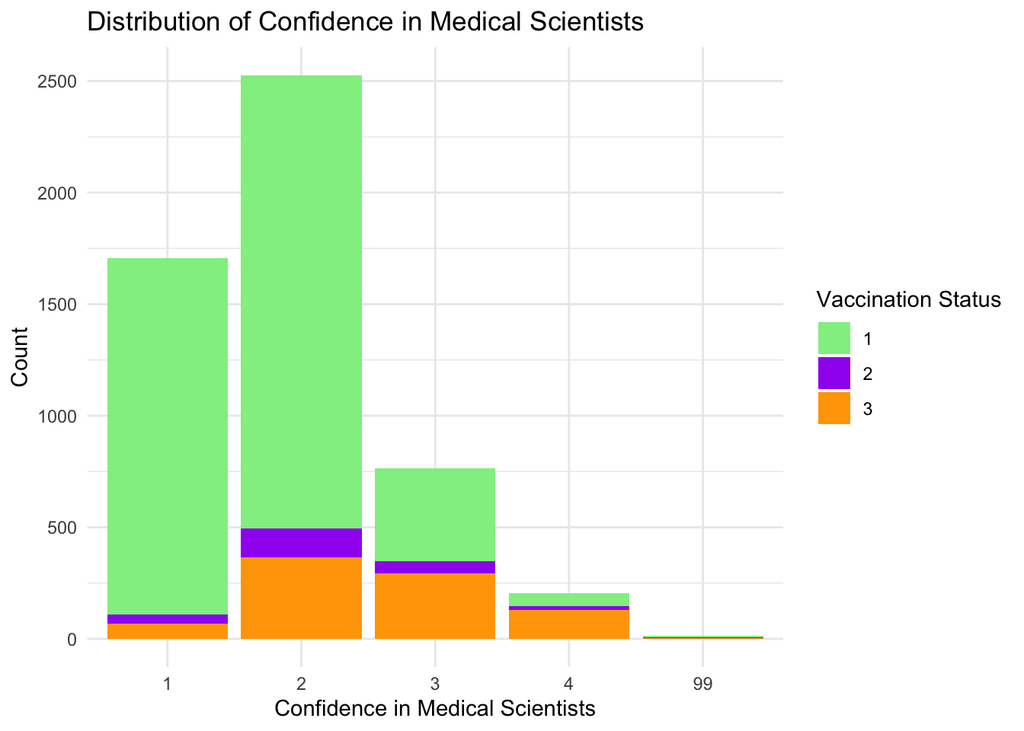

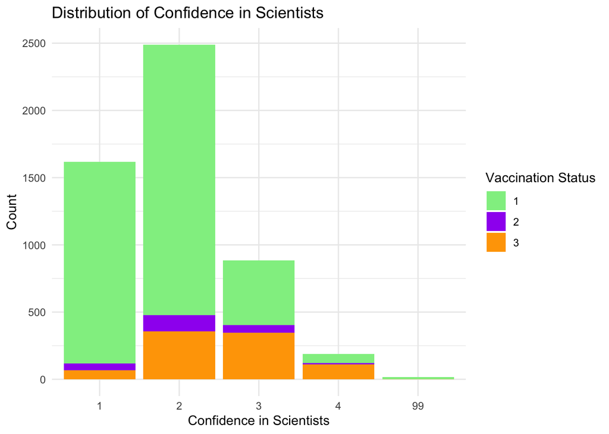

The same thing applied to RQ2_F1A_W114 and RQ2_SCI_W114:

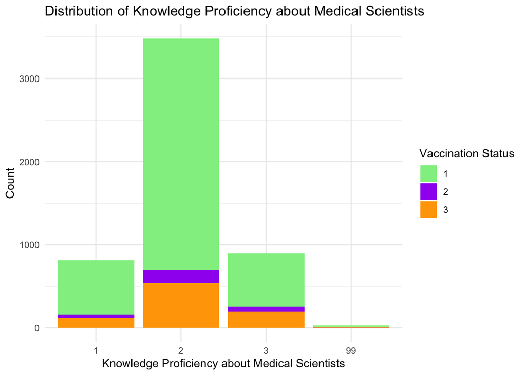

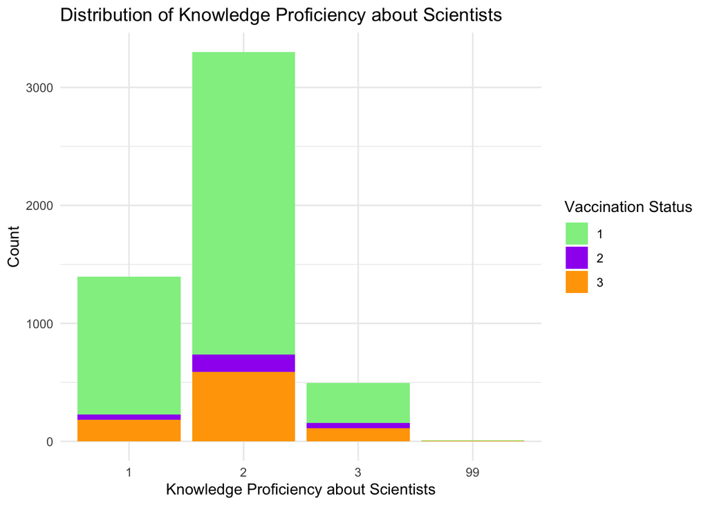

Measure the associations between CONF and the response variable:

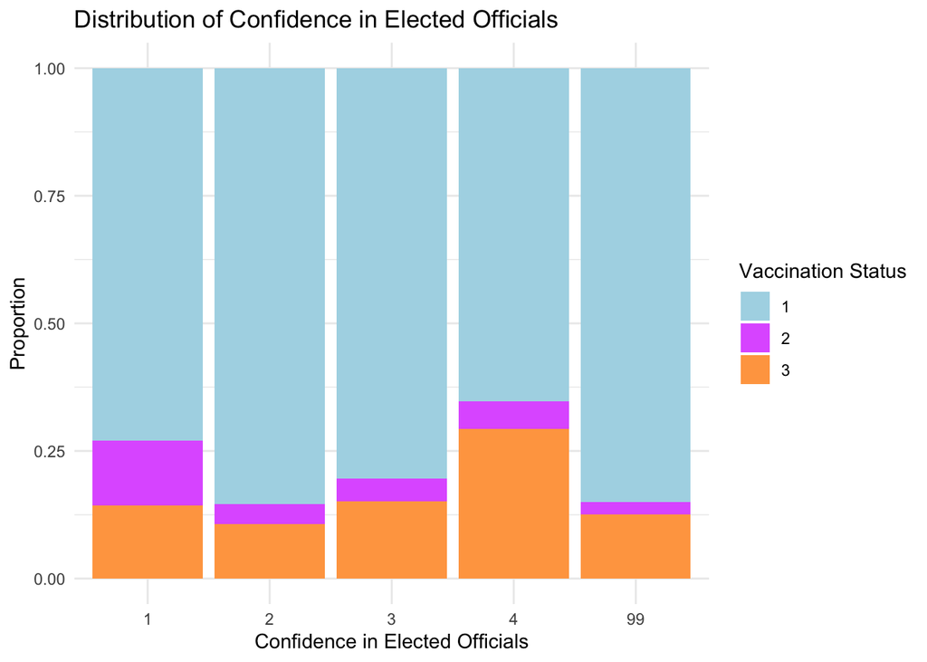

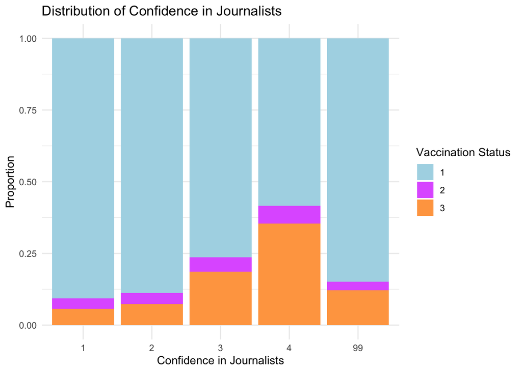

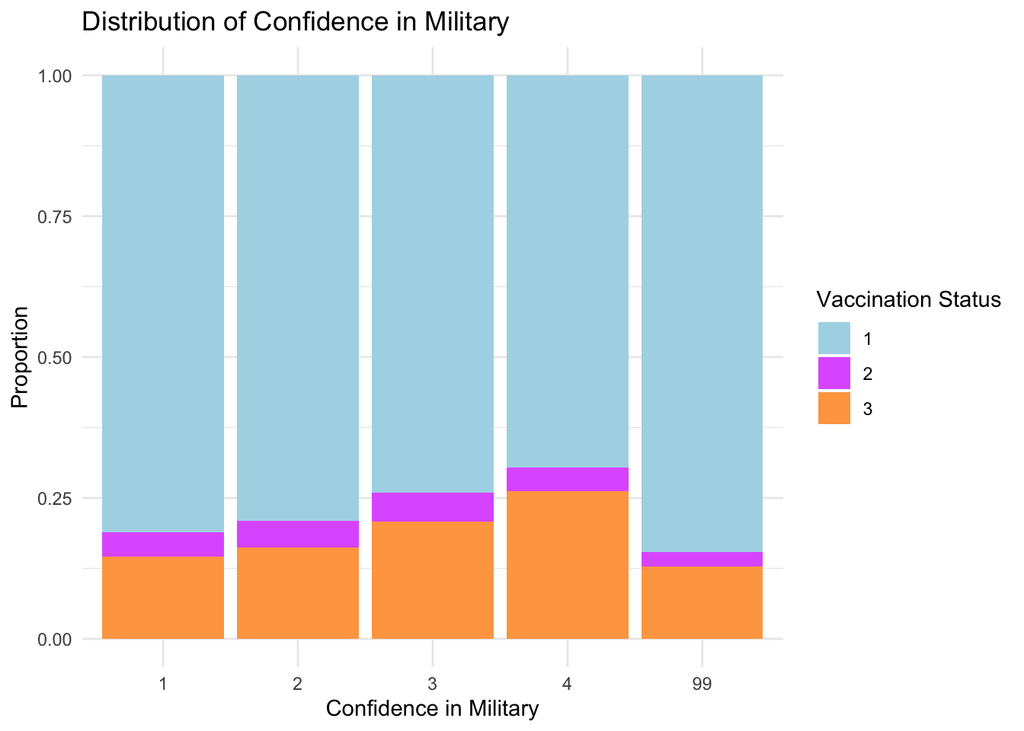

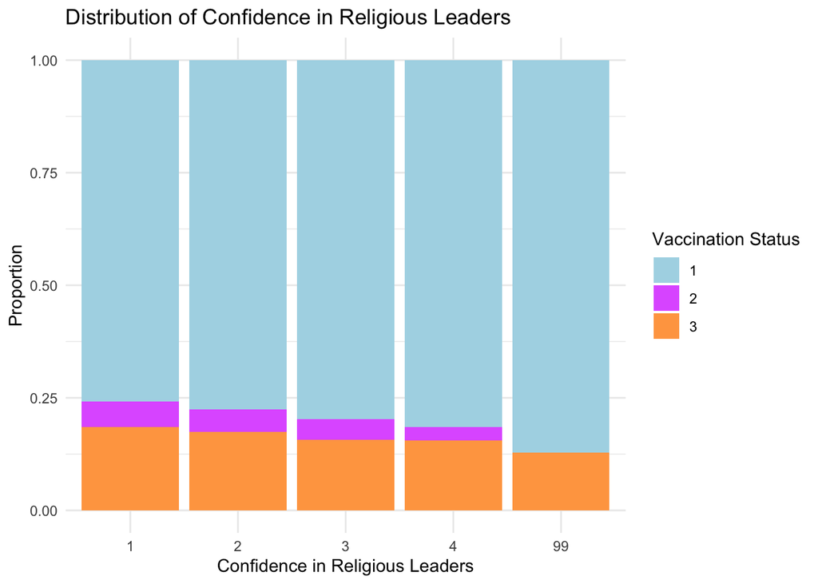

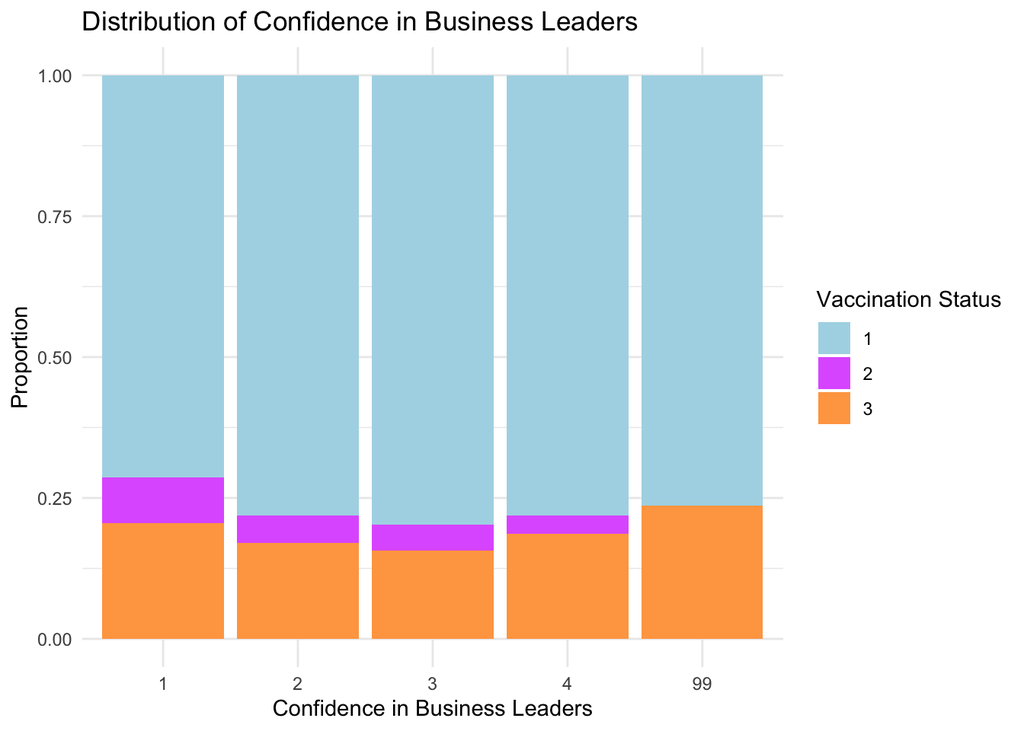

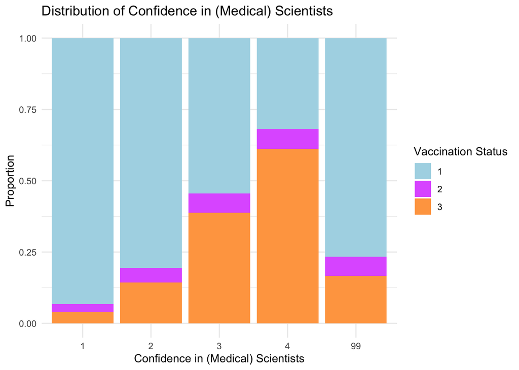

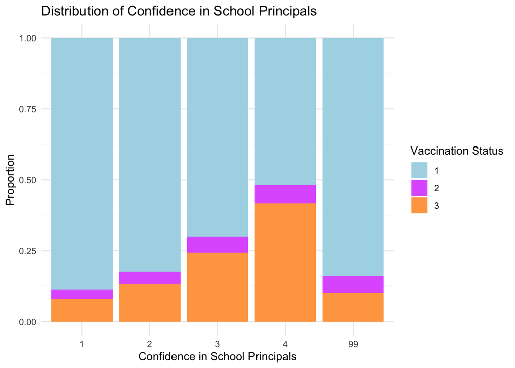

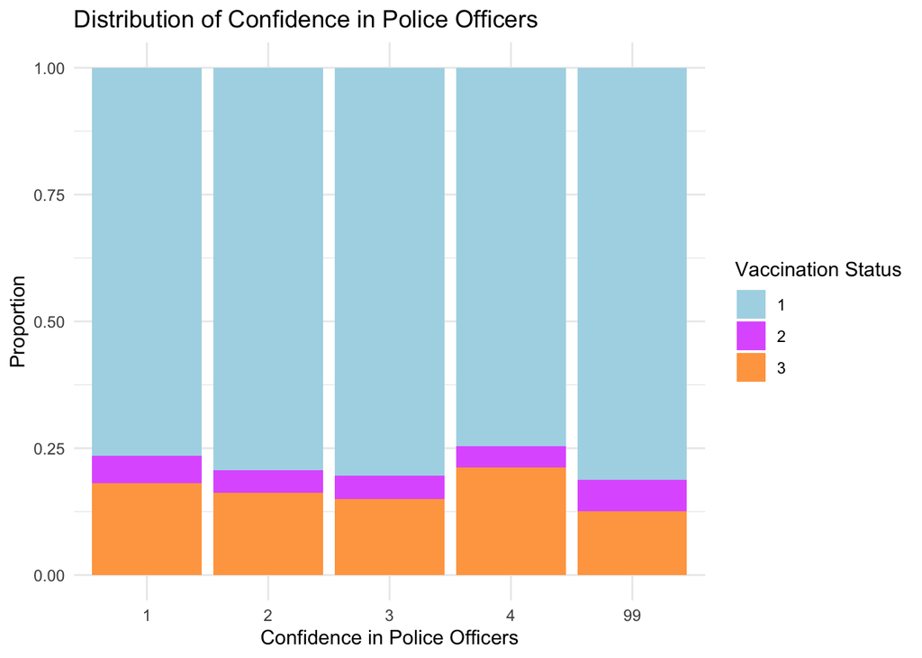

Plot of each CONF score with CONF_a (Elected officials)

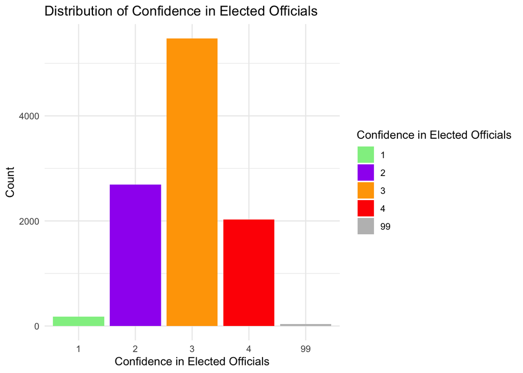

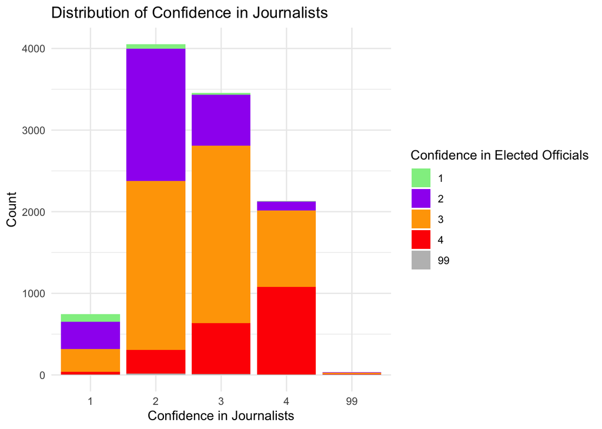

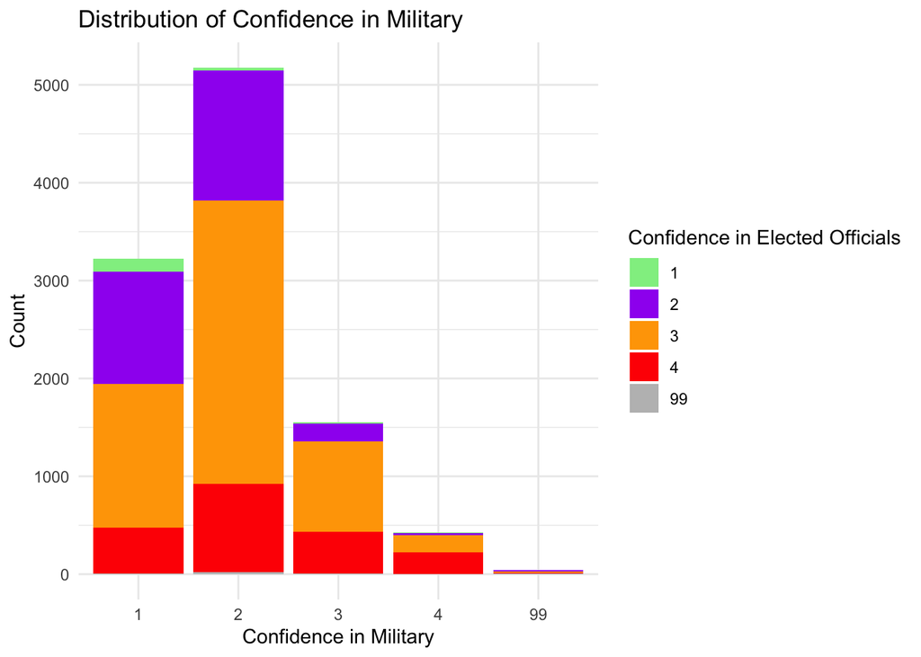

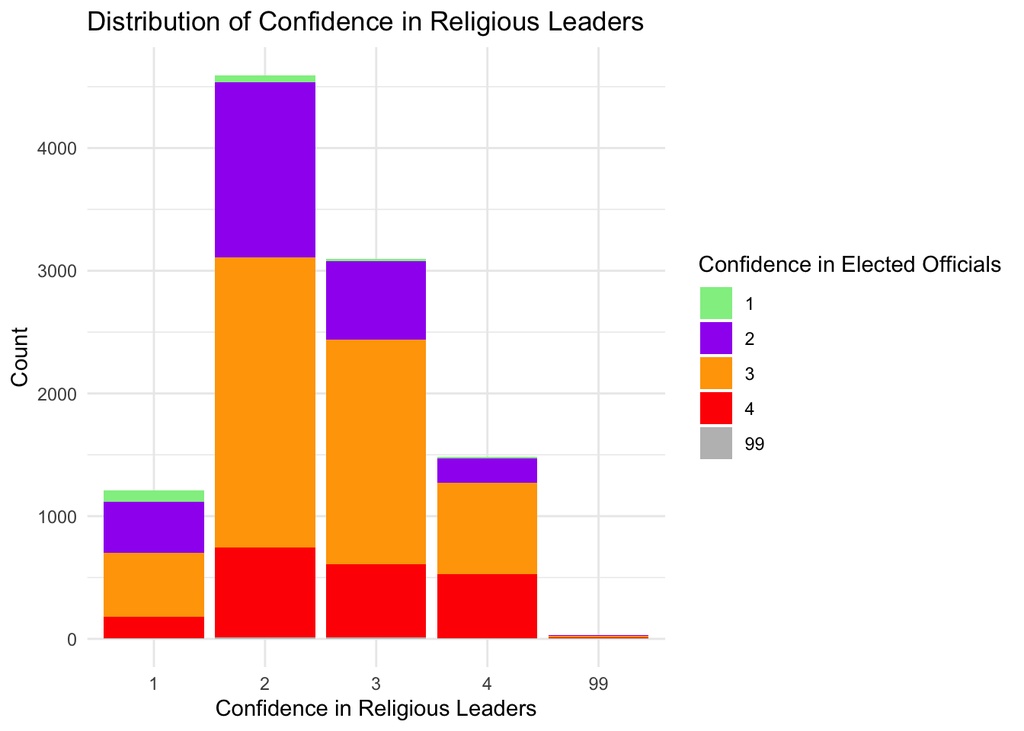

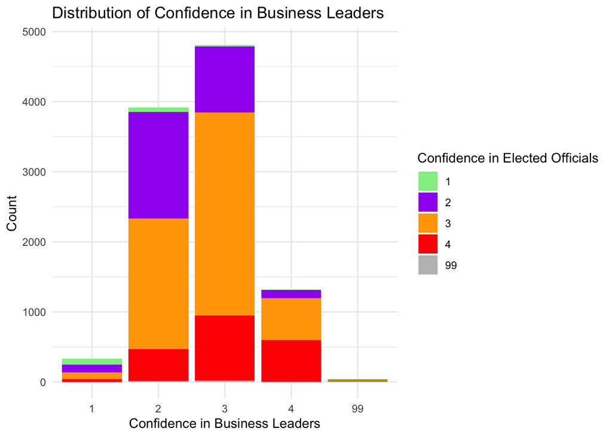

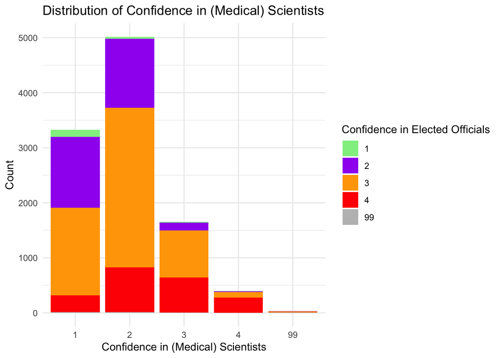

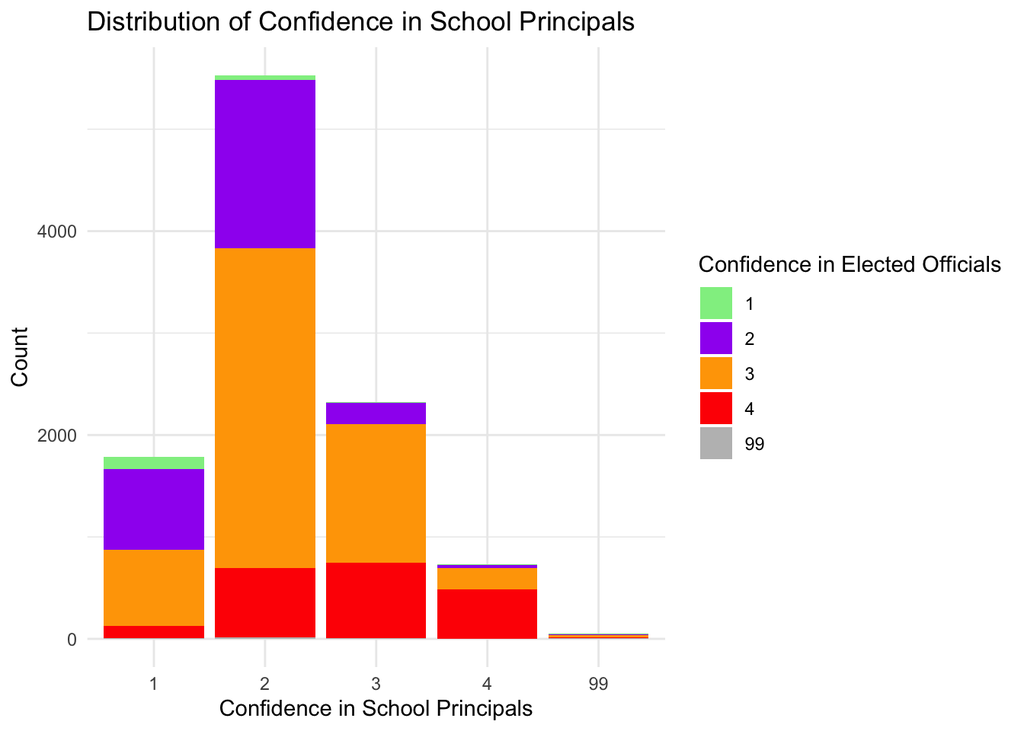

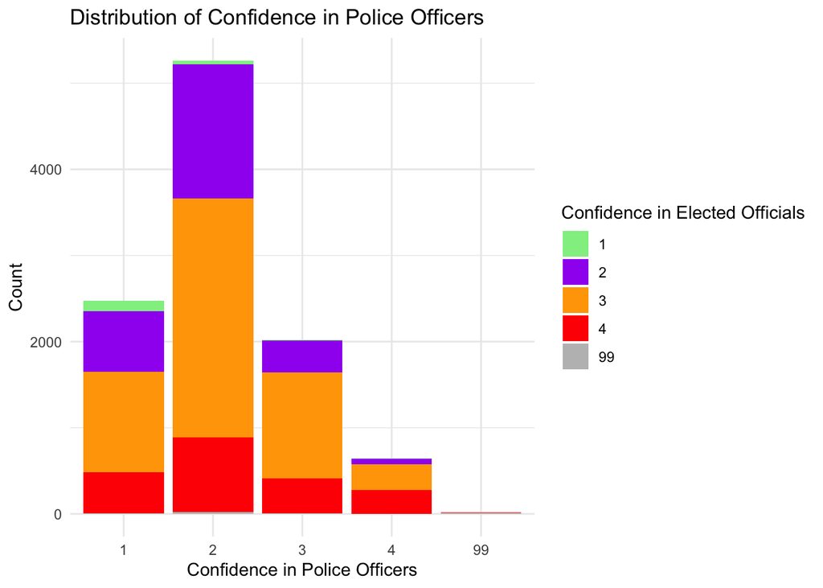

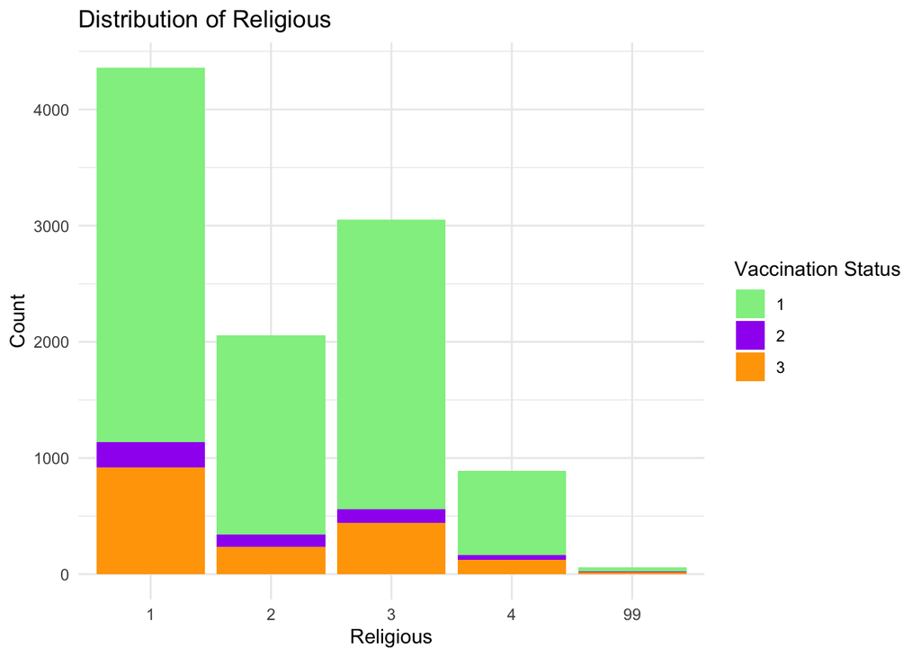

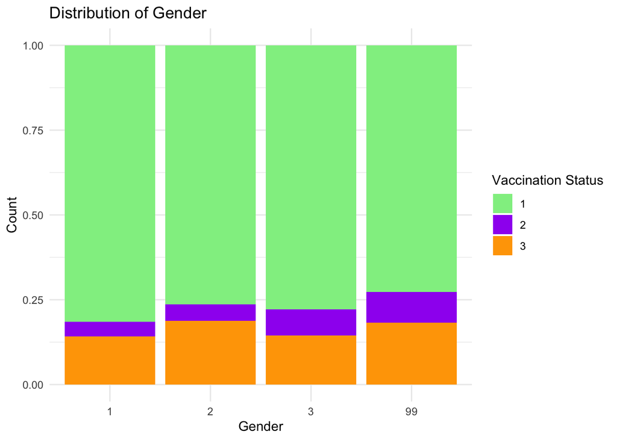

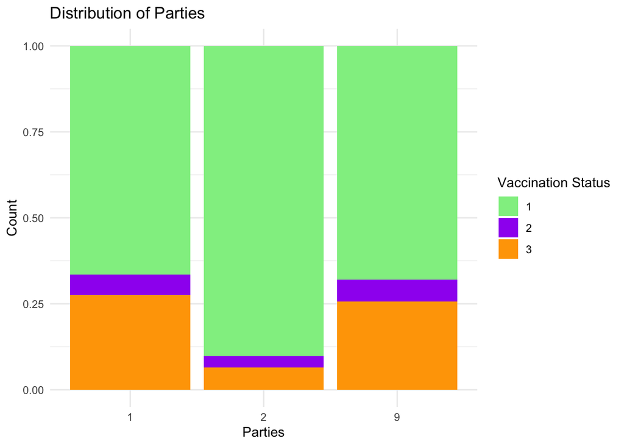

```
##                            Variable         Tau       p_value
##     Confidence in Elected Officials  0.14165047  2.314544e-53
##           Confidence in Journalists  0.25756886 2.723024e-178
##              Confidence in Military  0.05894825  1.364298e-10
##     Confidence in Religious Leaders -0.03485530  1.153503e-04
##      Confidence in Business Leaders -0.01443789  1.177320e-01
##  Confidence in (Medical) Scientists  0.33315621 9.079667e-289
##     Confidence in School Principals  0.20479325 1.169387e-111
##       Confidence in Police Officers -0.01412579  1.209704e-01
```

```
##                           Variable1                          Variable2
##     Confidence in Elected Officials          Confidence in Journalists
##     Confidence in Elected Officials             Confidence in Military
##     Confidence in Elected Officials    Confidence in Religious Leaders
##     Confidence in Elected Officials     Confidence in Business Leaders
##     Confidence in Elected Officials Confidence in (Medical) Scientists
##     Confidence in Elected Officials    Confidence in School Principals
##     Confidence in Elected Officials      Confidence in Police Officers
##           Confidence in Journalists             Confidence in Military
##           Confidence in Journalists    Confidence in Religious Leaders
##           Confidence in Journalists     Confidence in Business Leaders
##           Confidence in Journalists Confidence in (Medical) Scientists
##           Confidence in Journalists    Confidence in School Principals
##           Confidence in Journalists      Confidence in Police Officers
##              Confidence in Military    Confidence in Religious Leaders
##              Confidence in Military     Confidence in Business Leaders
##              Confidence in Military Confidence in (Medical) Scientists
##              Confidence in Military    Confidence in School Principals
##              Confidence in Military      Confidence in Police Officers
##     Confidence in Religious Leaders     Confidence in Business Leaders
##     Confidence in Religious Leaders Confidence in (Medical) Scientists
##     Confidence in Religious Leaders    Confidence in School Principals
##     Confidence in Religious Leaders      Confidence in Police Officers
##      Confidence in Business Leaders Confidence in (Medical) Scientists
##      Confidence in Business Leaders    Confidence in School Principals
##      Confidence in Business Leaders      Confidence in Police Officers
##  Confidence in (Medical) Scientists    Confidence in School Principals
##  Confidence in (Medical) Scientists      Confidence in Police Officers
##     Confidence in School Principals      Confidence in Police Officers
##       Confidence in Police Officers                               <NA>
##       Confidence in Police Officers      Confidence in Police Officers
##          Tau       p_value
##   0.41461299  0.000000e+00
##   0.21599409 1.442717e-131
##   0.18664953 8.054260e-102
##   0.29720065 9.153595e-245
##   0.31725257 5.887066e-282
##   0.37418445  0.000000e+00
##   0.12432011  1.607715e-45
##   0.07620295  1.827300e-18
##  -0.04418143  2.425073e-07
##   0.07646239  2.086728e-18
##   0.48106320  0.000000e+00
##   0.42967098  0.000000e+00
##  -0.09348286  2.181769e-27
##   0.31897090 2.597817e-295
##   0.34033180  0.000000e+00
##   0.17807689  8.851189e-91
##   0.22281679 1.207751e-142
##   0.45730386  0.000000e+00
##   0.34901520  0.000000e+00
##  -0.03060806  4.193349e-04
##   0.12466681  2.439306e-47
##   0.38760678  0.000000e+00
##   0.08668955  1.294740e-22
##   0.17136619  2.517287e-84
##   0.33405165  0.000000e+00
##   0.44564319  0.000000e+00
##   0.01551244  7.603373e-02
##   0.11333289  7.463402e-39
##  -0.01412579  1.209704e-01
##   1.00000000  0.000000e+00
```

## Part 4: Build a model to identify risk factors for non-vaccination

Represent the variable names in a more audeince-friendly way

Some preparations before the baseline model: 1. CONF_a_W114 option 1 2. F_GENDER option 3 3. Delete all 99s

Represent the labels within each variable to a more audience-friendly way.

```
## tibble [10,122 × 9] (S3: tbl_df/tbl/data.frame)
##  $ VACCINATED: Factor w/ 3 levels "Y","P","N": 1 1 1 3 1 3 1 1 1 1 ...
##  $ CONF_GOV  : Factor w/ 4 levels "H","M","L","N": 3 3 2 4 4 4 4 4 3 2 ...
##  $ CONF_SCI  : Factor w/ 4 levels "H","M","L","N": 2 1 1 3 4 4 3 3 2 1 ...
##  $ CONF_EDU  : Factor w/ 4 levels "H","M","L","N": 2 1 1 3 2 3 3 4 3 2 ...
##  $ AGE       : dbl+lbl [1:10122] 4, 2, 3, 4, 4, 3, 3, 3, 1, 4, 4, 4, 4, 3, 4, 4, 4, 4...
##    ..@ label      : chr "Age category"
##    ..@ format.spss: chr "F8.2"
##    ..@ labels     : Named num [1:5] 1 2 3 4 99
##    .. ..- attr(*, "names")= chr [1:5] "18-29" "30-49" "50-64" "65+" ...
##  $ RELIG     : Factor w/ 4 levels "PRTST","CTHLC",..: 1 2 1 1 1 1 1 3 1 3 ...
##  $ PARTY     : Factor w/ 3 levels "REPUB","DEMOC",..: 1 2 1 1 1 1 1 1 1 2 ...
##  $ GENDER    : Factor w/ 3 levels "M","F","OTHER": 1 2 2 2 1 2 2 1 2 2 ...
##  $ WEIGHT    : num [1:10122] 0.607 0.508 0.403 0.476 0.655 ...
##   ..- attr(*, "label")= chr "Wave 114 weight"
##   ..- attr(*, "format.spss")= chr "F8.2"
```

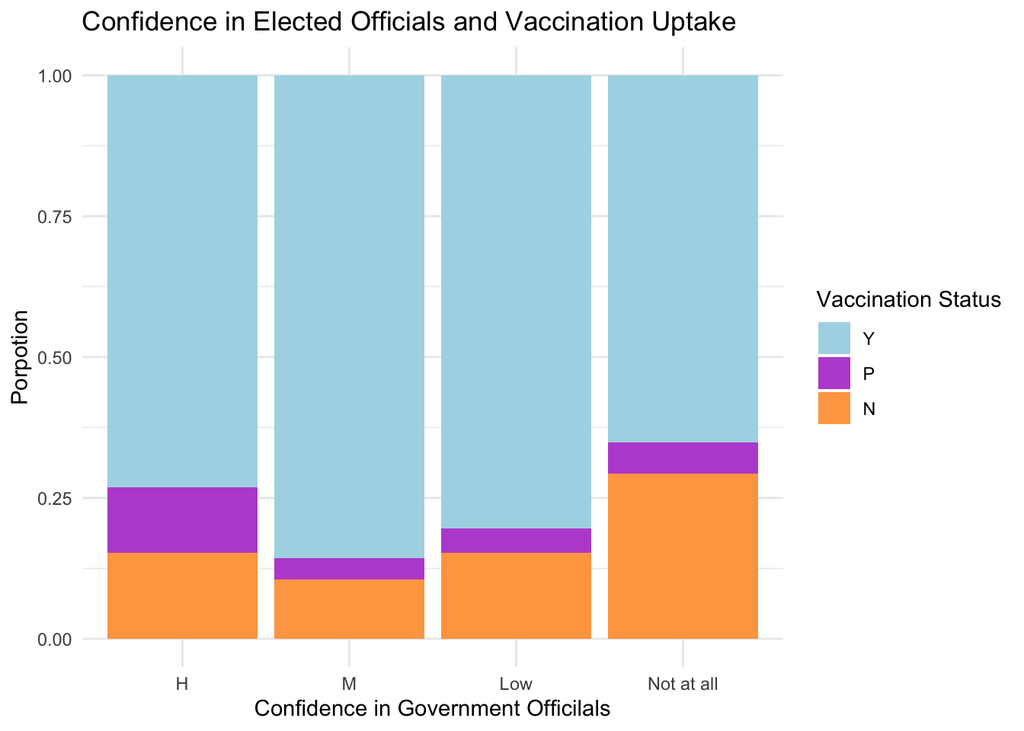

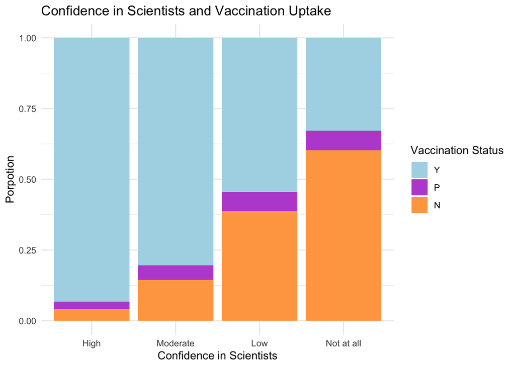

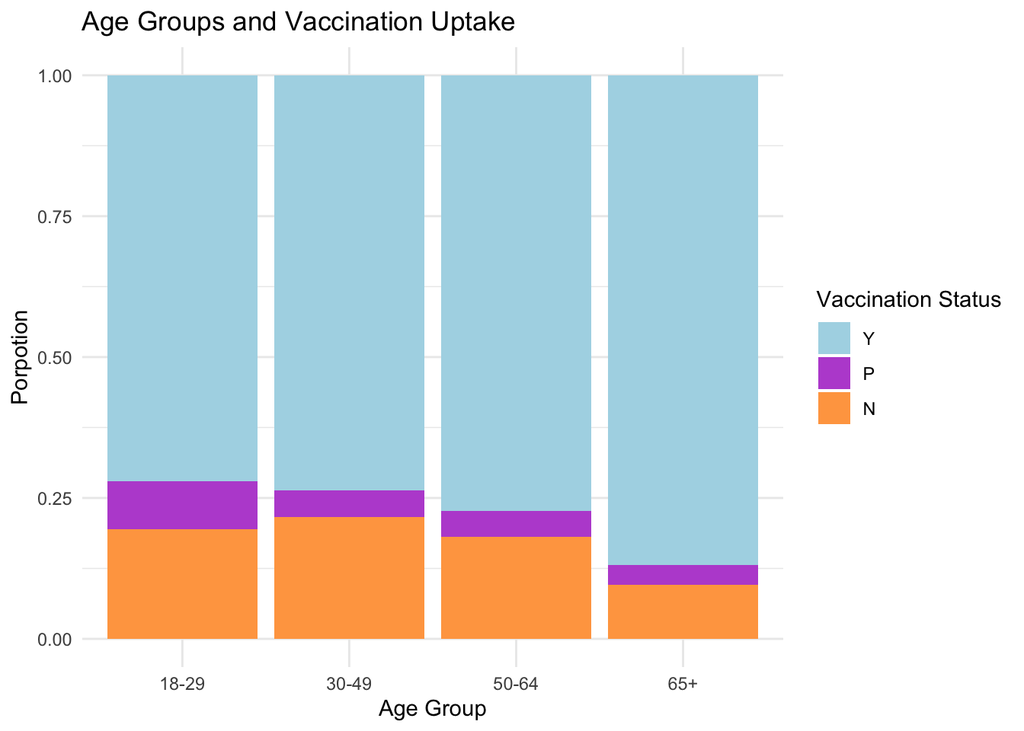

Baseline model based on CONF scores analysis:

```
## Call:
## polr(formula = VACCINATED ~ . - WEIGHT, data = ordinal_data,
##     Hess = TRUE)
##
## Coefficients:
##                Value Std. Error   t value
## CONF_GOVH   0.877558    0.20994   4.18003
## CONF_GOVM   0.035488    0.09061   0.39166
## CONF_GOVL  -0.095750    0.07008  -1.36625
## CONF_SCIH  -2.693710    0.14634 -18.40775
## CONF_SCIM  -1.797015    0.12599 -14.26283
## CONF_SCIL  -0.751480    0.12423  -6.04926
## CONF_EDUH  -0.469911    0.13279  -3.53864
## CONF_EDUM  -0.407528    0.10343  -3.93996
## CONF_EDUL  -0.301508    0.10064  -2.99578
## AGE2       -0.273646    0.09774  -2.79976
## AGE3       -0.712433    0.10237  -6.95946
## AGE4       -1.490812    0.10850 -13.74020
## RELIGCTHLC -0.484387    0.07619  -6.35744
## RELIGUNFFL -0.005469    0.07006  -0.07806
## RELIGOTHER -0.222857    0.10667  -2.08922
## PARTYREPUB  0.133874    0.15035   0.89043
## PARTYDEMOC -1.183231    0.15469  -7.64896
## GENDERM    -0.460526    0.05671  -8.12069
##
## Intercepts:
##     Value    Std. Error t value
## Y|P  -2.1385   0.2119   -10.0938
## P|N  -1.7576   0.2114    -8.3158
##
## Residual Deviance: 10460.73
## AIC: 10500.73
```

Alternative mymodel2 (changes in difference between three levels)

```
## Call:
## polr(formula = VACCINATED ~ . - WEIGHT, data = level_changed_data,
##     Hess = TRUE)
##
## Coefficients:
##                Value Std. Error   t value
## CONF_GOVH   0.877558    0.20994   4.18003
## CONF_GOVM   0.035488    0.09061   0.39166
## CONF_GOVL  -0.095750    0.07008  -1.36625
## CONF_SCIH  -2.693710    0.14634 -18.40775
## CONF_SCIM  -1.797015    0.12599 -14.26283
## CONF_SCIL  -0.751480    0.12423  -6.04926
## CONF_EDUH  -0.469911    0.13279  -3.53864
## CONF_EDUM  -0.407528    0.10343  -3.93996
## CONF_EDUL  -0.301508    0.10064  -2.99578
## AGE2       -0.273646    0.09774  -2.79976
## AGE3       -0.712433    0.10237  -6.95946
## AGE4       -1.490812    0.10850 -13.74020
## RELIGCTHLC -0.484387    0.07619  -6.35744
## RELIGUNFFL -0.005469    0.07006  -0.07806
## RELIGOTHER -0.222857    0.10667  -2.08922
## PARTYREPUB  0.133874    0.15035   0.89043
## PARTYDEMOC -1.183231    0.15469  -7.64896
## GENDERM    -0.460526    0.05671  -8.12069
##
## Intercepts:
##     Value    Std. Error t value
## Y|P  -2.1385   0.2119   -10.0938
## P|N  -1.7576   0.2114    -8.3158
##
## Residual Deviance: 10460.73
## AIC: 10500.73
```

Alternative mymodel3 (Treat confidence score as ordered)

```
## Call:
## polr(formula = VACCINATED ~ . - WEIGHT, data = orrdered_conf_data,
##     Hess = TRUE)
##
## Coefficients:
##                Value Std. Error   t value
## CONF_GOV.L -0.252522    0.06595  -3.82904
## CONF_GOV.Q -0.504390    0.11391  -4.42790
## CONF_GOV.C  0.543463    0.13895   3.91122
## CONF_SCI.L -0.303612    0.08552  -3.55002
## CONF_SCI.Q  1.869632    0.08549  21.86874
## CONF_SCI.C -0.769560    0.06474 -11.88649
## CONF_EDU.L -0.188291    0.07085  -2.65752
## CONF_EDU.Q  0.287951    0.07933   3.62974
## CONF_EDU.C -0.109264    0.06837  -1.59817
## AGE2       -0.273637    0.09774  -2.79966
## AGE3       -0.712429    0.10237  -6.95940
## AGE4       -1.490800    0.10850 -13.74007
## RELIGCTHLC -0.484383    0.07619  -6.35739
## RELIGUNFFL -0.005476    0.07006  -0.07816
## RELIGOTHER -0.222850    0.10667  -2.08915
## PARTYREPUB  0.133871    0.15035   0.89042
## PARTYDEMOC -1.183239    0.15469  -7.64901
## GENDERM    -0.460525    0.05671  -8.12067
##
## Intercepts:
##     Value    Std. Error t value
## Y|P  -0.7375   0.1813    -4.0684
## P|N  -0.3567   0.1812    -1.9685
##
## Residual Deviance: 10460.73
## AIC: 10500.73
```

Alternative mymodel4: WEIGHT_W114 accounted (based on mymodel1)

```
## Call:
## polr(formula = VACCINATED ~ CONF_GOV + RELIG + PARTY + GENDER +
##     AGE, data = ordinal_data, weights = WEIGHT, Hess = TRUE)
##
## Coefficients:
##              Value Std. Error t value
## CONF_GOVH   0.2248    0.14817   1.517
## CONF_GOVM  -0.4817    0.07022  -6.859
## CONF_GOVL  -0.4403    0.05860  -7.514
## RELIGCTHLC -0.5436    0.06686  -8.130
## RELIGUNFFL -0.1271    0.06013  -2.114
## RELIGOTHER -0.3903    0.09488  -4.114
## PARTYREPUB  0.1750    0.09661   1.811
## PARTYDEMOC -1.3762    0.09997 -13.766
## GENDERM    -0.4336    0.04866  -8.910
## AGE2       -0.1658    0.06507  -2.548
## AGE3       -0.5786    0.07226  -8.008
## AGE4       -1.3281    0.08327 -15.950
##
## Intercepts:
##     Value    Std. Error t value
## Y|P  -0.6764   0.1179    -5.7367
## P|N  -0.2868   0.1178    -2.4351
##
## Residual Deviance: 13115.42
## AIC: 13143.42
```

```
## Call:
## polr(formula = VACCINATED ~ CONF_EDU + AGE + RELIG + PARTY +
##     GENDER, data = ordinal_data, weights = WEIGHT, Hess = TRUE)
##
## Coefficients:
##              Value Std. Error t value
## CONF_EDUH  -1.2974    0.10404 -12.470
## CONF_EDUM  -1.0109    0.08206 -12.319
## CONF_EDUL  -0.6487    0.08652  -7.497
## AGE2       -0.1753    0.06520  -2.688
## AGE3       -0.6052    0.07271  -8.322
## AGE4       -1.3708    0.08388 -16.343
## RELIGCTHLC -0.5796    0.06725  -8.618
## RELIGUNFFL -0.1465    0.06031  -2.429
## RELIGOTHER -0.4007    0.09564  -4.189
## PARTYREPUB  0.1635    0.09737   1.679
## PARTYDEMOC -1.2962    0.10053 -12.894
## GENDERM    -0.4625    0.04897  -9.443
##
## Intercepts:
##     Value    Std. Error t value
## Y|P  -1.2229   0.1344    -9.0982
## P|N  -0.8279   0.1341    -6.1739
##
## Residual Deviance: 12992.42
## AIC: 13020.42
```

Pearson chi-squared test between confidence scores

```
##                  Pair Chi_Square p_value
## 1 CONF_GOV & CONF_SCI   1712.458       0
## 2 CONF_GOV & CONF_EDU   2348.416       0
## 3 CONF_SCI & CONF_EDU   3687.522       0
```

Combine completely vaccinated and one dose: Non vaccinations only for people who are not vaccinated at all

```
##
##    N    Y
## 1695 8427
```

```
##
## Call:
## glm(formula = I(VACCINATED == "N") ~ CONF_SCI + AGE + RELIG +
##     PARTY + GENDER, family = binomial, data = data_YP)
##
## Coefficients:
##             Estimate Std. Error z value Pr(>|z|)
## (Intercept)  1.49272    0.22075   6.762 1.36e-11 ***
## CONF_SCIH   -3.03104    0.14587 -20.780  < 2e-16 ***
## CONF_SCIM   -2.06333    0.12029 -17.153  < 2e-16 ***
## CONF_SCIL   -0.89461    0.12382  -7.225 5.02e-13 ***
## AGE2        -0.12661    0.11205  -1.130    0.259
## AGE3        -0.59519    0.11709  -5.083 3.71e-07 ***
## AGE4        -1.41364    0.12474 -11.333  < 2e-16 ***
## RELIGCTHLC  -0.59729    0.08781  -6.802 1.03e-11 ***
## RELIGUNFFL   0.07714    0.07719   0.999    0.318
## RELIGOTHER  -0.18846    0.11939  -1.579    0.114
## PARTYREPUB   0.17592    0.16289   1.080    0.280
## PARTYDEMOC  -1.28505    0.16949  -7.582 3.41e-14 ***
## GENDERM     -0.49454    0.06293  -7.859 3.88e-15 ***
## ---
## Signif. codes:  0 '***' 0.001 '**' 0.01 '*' 0.05 '.' 0.1 ' ' 1
##
## (Dispersion parameter for binomial family taken to be 1)
##
##     Null deviance: 9146.9  on 10121  degrees of freedom
## Residual deviance: 7088.5  on 10109  degrees of freedom
## AIC: 7114.5
##
## Number of Fisher Scoring iterations: 6
```

```
##
## Call:
## glm(formula = I(VACCINATED == "N") ~ . - WEIGHT - VACCINATED,
##     family = binomial, data = data_YP, weights = WEIGHT)
##
## Coefficients:
##             Estimate Std. Error z value Pr(>|z|)
## (Intercept)  1.27439    0.17267   7.380 1.58e-13 ***
## CONF_GOVH    0.57177    0.19896   2.874 0.004055 **
## CONF_GOVM    0.20197    0.09014   2.241 0.025051 *
## CONF_GOVL   -0.02315    0.07206  -0.321 0.748003
## CONF_SCIH   -2.22841    0.14372 -15.505  < 2e-16 ***
## CONF_SCIM   -1.36551    0.12356 -11.051  < 2e-16 ***
## CONF_SCIL   -0.36992    0.12201  -3.032 0.002431 **
## CONF_EDUH   -0.45236    0.13357  -3.387 0.000708 ***
## CONF_EDUM   -0.43241    0.10338  -4.183 2.88e-05 ***
## CONF_EDUL   -0.41039    0.10208  -4.020 5.81e-05 ***
## AGE2        -0.03418    0.07596  -0.450 0.652697
## AGE3        -0.53708    0.08517  -6.306 2.86e-10 ***
## AGE4        -1.24259    0.09813 -12.663  < 2e-16 ***
## RELIGCTHLC  -0.70086    0.08071  -8.683  < 2e-16 ***
## RELIGUNFFL   0.13590    0.06925   1.963 0.049704 *
## RELIGOTHER  -0.34740    0.11364  -3.057 0.002235 **
## PARTYREPUB   0.21779    0.10895   1.999 0.045614 *
## PARTYDEMOC  -1.15701    0.11506 -10.056  < 2e-16 ***
## GENDERM     -0.44474    0.05652  -7.869 3.57e-15 ***
## ---
## Signif. codes:  0 '***' 0.001 '**' 0.01 '*' 0.05 '.' 0.1 ' ' 1
##
## (Dispersion parameter for binomial family taken to be 1)
##
##     Null deviance: 10314.8  on 10121  degrees of freedom
## Residual deviance:  8343.2  on 10103  degrees of freedom
## AIC: 8241.2
##
## Number of Fisher Scoring iterations: 5
```

Combine not vaccinated and one dose: Non vaccinations for people who are not fully vaccinated or not at all (people who took only one does might be forced for flight travel or school entry requirements)

```
##
##    N    Y
## 2160 7962
```

```
##
## Call:
## glm(formula = I(VACCINATED == "N") ~ . - WEIGHT - VACCINATED,
##     family = binomial, data = data_PN)
##
## Coefficients:
##             Estimate Std. Error z value Pr(>|z|)
## (Intercept)  2.18212    0.21939   9.946  < 2e-16 ***
## CONF_GOVH    1.06084    0.21564   4.919 8.68e-07 ***
## CONF_GOVM    0.06254    0.09216   0.679 0.497341
## CONF_GOVL   -0.08318    0.07157  -1.162 0.245152
## CONF_SCIH   -2.67925    0.15169 -17.663  < 2e-16 ***
## CONF_SCIM   -1.77190    0.13194 -13.430  < 2e-16 ***
## CONF_SCIL   -0.76264    0.13057  -5.841 5.19e-09 ***
## CONF_EDUH   -0.50073    0.13559  -3.693 0.000222 ***
## CONF_EDUM   -0.43385    0.10628  -4.082 4.47e-05 ***
## CONF_EDUL   -0.32252    0.10363  -3.112 0.001857 **
## AGE2        -0.34653    0.10023  -3.458 0.000545 ***
## AGE3        -0.77763    0.10494  -7.410 1.26e-13 ***
## AGE4        -1.53877    0.11090 -13.875  < 2e-16 ***
## RELIGCTHLC  -0.45265    0.07735  -5.852 4.86e-09 ***
## RELIGUNFFL  -0.01070    0.07121  -0.150 0.880557
## RELIGOTHER  -0.21580    0.10845  -1.990 0.046606 *
## PARTYREPUB   0.10798    0.15346   0.704 0.481669
## PARTYDEMOC  -1.17522    0.15777  -7.449 9.42e-14 ***
## GENDERM     -0.44751    0.05762  -7.767 8.02e-15 ***
## ---
## Signif. codes:  0 '***' 0.001 '**' 0.01 '*' 0.05 '.' 0.1 ' ' 1
##
## (Dispersion parameter for binomial family taken to be 1)
##
##     Null deviance: 10494.9  on 10121  degrees of freedom
## Residual deviance:  8318.1  on 10103  degrees of freedom
## AIC: 8356.1
##
## Number of Fisher Scoring iterations: 5
```

Alternative mymodel8: mymodel7 with weights WEIGHT_W114

```
##
## Call:
## glm(formula = I(VACCINATED == "N") ~ . - WEIGHT - VACCINATED,
##     family = binomial, data = data_PN, weights = WEIGHT)
##
## Coefficients:
##             Estimate Std. Error z value Pr(>|z|)
## (Intercept)  1.78567    0.16809  10.624  < 2e-16 ***
## CONF_GOVH    1.21419    0.17186   7.065 1.61e-12 ***
## CONF_GOVM    0.24222    0.08269   2.929 0.003399 **
## CONF_GOVL   -0.02813    0.06750  -0.417 0.676873
## CONF_SCIH   -2.13578    0.13728 -15.557  < 2e-16 ***
## CONF_SCIM   -1.33524    0.12292 -10.863  < 2e-16 ***
## CONF_SCIL   -0.39405    0.12285  -3.208 0.001338 **
## CONF_EDUH   -0.46489    0.12400  -3.749 0.000178 ***
## CONF_EDUM   -0.38289    0.09920  -3.860 0.000113 ***
## CONF_EDUL   -0.30759    0.09851  -3.123 0.001793 **
## AGE2        -0.30135    0.06929  -4.349 1.37e-05 ***
## AGE3        -0.74633    0.07743  -9.638  < 2e-16 ***
## AGE4        -1.46388    0.08835 -16.569  < 2e-16 ***
## RELIGCTHLC  -0.42512    0.07049  -6.031 1.63e-09 ***
## RELIGUNFFL   0.06800    0.06457   1.053 0.292305
## RELIGOTHER  -0.20057    0.10108  -1.984 0.047238 *
## PARTYREPUB   0.12486    0.10405   1.200 0.230117
## PARTYDEMOC  -1.13387    0.10776 -10.522  < 2e-16 ***
## GENDERM     -0.41930    0.05169  -8.113 4.95e-16 ***
## ---
## Signif. codes:  0 '***' 0.001 '**' 0.01 '*' 0.05 '.' 0.1 ' ' 1
##
## (Dispersion parameter for binomial family taken to be 1)
##
##     Null deviance: 11724.9  on 10121  degrees of freedom
## Residual deviance:  9643.2  on 10103  degrees of freedom
## AIC: 9484
##
## Number of Fisher Scoring iterations: 5
```

Interaction model

```
## Call:
## polr(formula = VACCINATED ~ CONF_SCI * AGE_num + GENDER + PARTY +
##     RELIG, data = interaction_data, weights = WEIGHT, Hess = TRUE)
##
## Coefficients:
##                      Value Std. Error  t value
## CONF_SCIH         -1.84856    0.34013  -5.4349
## CONF_SCIM         -1.07354    0.32065  -3.3480
## CONF_SCIL          0.15570    0.33635   0.4629
## AGE_num           -0.27432    0.10945  -2.5063
## GENDERM           -0.39870    0.05009  -7.9592
## PARTYREPUB         0.17179    0.10029   1.7129
## PARTYDEMOC        -1.11936    0.10362 -10.8022
## RELIGCTHLC        -0.49546    0.06904  -7.1765
## RELIGUNFFL         0.05058    0.06202   0.8156
## RELIGOTHER        -0.25162    0.09824  -2.5613
## CONF_SCIH:AGE_num -0.14766    0.12426  -1.1883
## CONF_SCIM:AGE_num -0.16942    0.11439  -1.4810
## CONF_SCIL:AGE_num -0.26226    0.11991  -2.1872
##
## Intercepts:
##     Value    Std. Error t value
## Y|P  -1.7235   0.3223    -5.3478
## P|N  -1.3073   0.3220    -4.0594
##
## Residual Deviance: 12527.23
## AIC: 12557.23
```

```
## Call:
## polr(formula = VACCINATED ~ CONF_GOV * AGE + CONF_SCI * AGE +
##     CONF_EDU * AGE, data = ordinal_data, weights = WEIGHT, Hess = TRUE)
##
## Coefficients:
##                   Value Std. Error  t value
## CONF_GOVH       0.59786     0.2516  2.37576
## CONF_GOVM       0.03629     0.1567  0.23163
## CONF_GOVL      -0.14721     0.1303 -1.12989
## AGE2           -0.32492     0.3903 -0.83238
## AGE3           -0.51400     0.3967 -1.29562
## AGE4           -0.48901     0.4226 -1.15721
## CONF_SCIH      -2.39718     0.3456 -6.93570
## CONF_SCIM      -1.17593     0.3312 -3.55090
## CONF_SCIL      -0.30116     0.3426 -0.87903
## CONF_EDUH      -0.01260     0.2492 -0.05054
## CONF_EDUM      -0.76414     0.2130 -3.58724
## CONF_EDUL      -0.55372     0.2187 -2.53139
## CONF_GOVH:AGE2  1.24394     0.3722  3.34209
## CONF_GOVM:AGE2  0.24429     0.2034  1.20120
## CONF_GOVL:AGE2  0.34491     0.1715  2.01163
## CONF_GOVH:AGE3 -0.29678     0.4600 -0.64514
## CONF_GOVM:AGE3 -0.51126     0.2257 -2.26476
## CONF_GOVL:AGE3 -0.10132     0.1785 -0.56751
## CONF_GOVH:AGE4 -3.23640     2.0324 -1.59239
## CONF_GOVM:AGE4  0.38798     0.2535  1.53048
## CONF_GOVL:AGE4 -0.20389     0.2085 -0.97802
## AGE2:CONF_SCIH -0.44430     0.4102 -1.08303
## AGE3:CONF_SCIH  0.24242     0.4183  0.57949
## AGE4:CONF_SCIH -0.37834     0.4658 -0.81232
## AGE2:CONF_SCIM -0.74046     0.3873 -1.91190
## AGE3:CONF_SCIM -0.10231     0.3872 -0.26425
## AGE4:CONF_SCIM -0.38374     0.4170 -0.92034
## AGE2:CONF_SCIL -0.16884     0.3963 -0.42599
## AGE3:CONF_SCIL  0.13634     0.3949  0.34520
## AGE4:CONF_SCIL -0.47756     0.4226 -1.12995
## AGE2:CONF_EDUH -0.29463     0.3211 -0.91743
## AGE3:CONF_EDUH -0.96713     0.3510 -2.75505
## AGE4:CONF_EDUH -1.13828     0.3915 -2.90729
## AGE2:CONF_EDUM  0.77620     0.2695  2.88009
## AGE3:CONF_EDUM  0.45831     0.2794  1.64028
## AGE4:CONF_EDUM -0.23429     0.3061 -0.76539
## AGE2:CONF_EDUL  0.53579     0.2747  1.95024
## AGE3:CONF_EDUL  0.30754     0.2804  1.09671
## AGE4:CONF_EDUL  0.07665     0.2988  0.25652
##
## Intercepts:
##     Value   Std. Error t value
## Y|P -1.1756  0.3506    -3.3529
## P|N -0.7790  0.3505    -2.2228
##
## Residual Deviance: 12981.28
## AIC: 13063.28
```